# Содержание

- Анализ фильмов с государственной поддержкой в разрезе возрастного ограничения

```python
# создадим сводную таблицу, сгруппировав данные по возрастному ограничению, значениями выберем кассовый сбор и посчитаем
# количество, медианное значение и сумму, для рейтинга - среднее арифметическое
gov_age = gov_data.pivot_table(index = 'age_restriction', values = ['box_office','ratings'],\
aggfunc = {'box_office':['sum','count','median'],'ratings': 'mean'}).reset_index()

gov_age['ratings'] = round(gov_age['ratings'],1)
gov_age
```

|  | age_restriction | box_office count | box_office median | box_office sum | ratings mean |
| --- | --- | --- | --- | --- | --- |
| 0 | «0+» - для любой зрительской аудитории | 5 | 32,244,810.00 | 552,932,752.50 | 5.70 |
| 1 | «12+» - для детей старше 12 лет | 100 | 23,365,689.49 | 19,957,963,755.94 | 6.10 |
| 2 | «16+» - для детей старше 16 лет | 120 | 8,195,307.25 | 7,658,462,636.93 | 6.00 |
| 3 | «18+» - запрещено для детей | 28 | 1,828,557.75 | 560,158,730.15 | 6.30 |
| 4 | «6+» - для детей старше 6 лет | 65 | 66,504,721.61 | 13,383,991,699.26 | 6.00 |

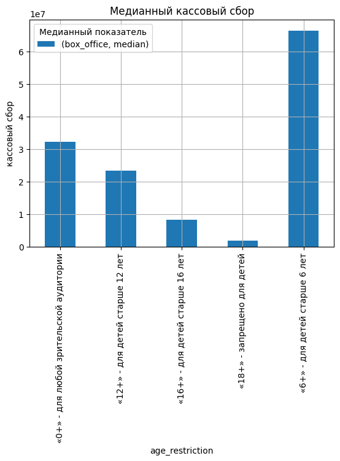

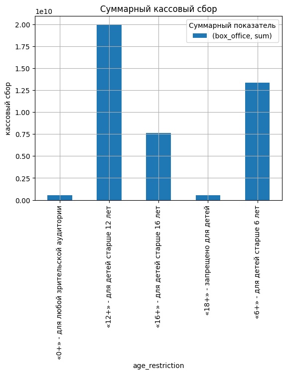

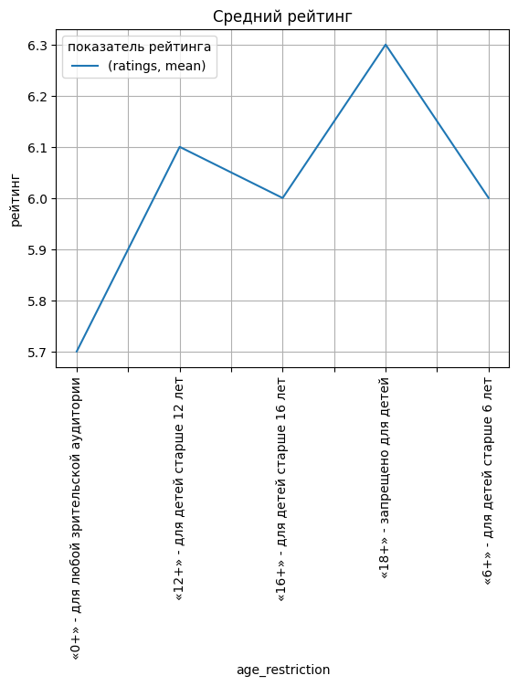

```python
# построим график зависимости медианного показателя от возрастного ограничения
gov_age.plot(kind = 'bar', x = 'age_restriction', y = ('box_office','median'), grid = True, \
             title = 'Медианный кассовый сбор')
plt.ylabel('кассовый сбор')
plt.legend(title = 'Медианный показатель');
# построим график зависимости суммарного кассового сбора и возрастного ограничения
gov_age.plot(kind = 'bar', x = 'age_restriction', y = ('box_office','sum'), grid = True, title = 'Суммарный кассовый сбор')
plt.ylabel('кассовый сбор')
plt.legend(title = 'Суммарный показатель');
# построим график зависимости рейтинга и возрастного ограничения
gov_age.plot( x = 'age_restriction', y = ('ratings','mean'), title = 'Средний рейтинг',rot = 90, grid = True)
plt.ylabel('рейтинг')
plt.legend(title = 'показатель рейтинга');
```

Рассмотрим динамику изменения суммарного показателя кассового сбора по годам в разрезе возрастного ограничения

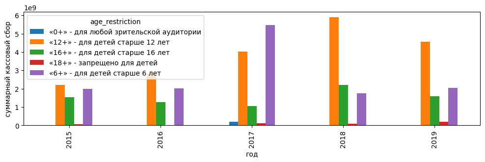

```python
#создадим сводную таблицу,сгруппировав данные по году, субгатегориями будут возрастные ограничения, данными - суммарный
# кассовый сбор, посторим диаграмму
gov_data.query('year_premier > 2014')\
.pivot_table(index = 'year_premier',columns = 'age_restriction', values = 'box_office', aggfunc = 'sum' )\
.plot(kind = 'bar',rot = 90, figsize = (12,3), ylabel = 'суммарный кассовый сбор',xlabel = 'год' );
```

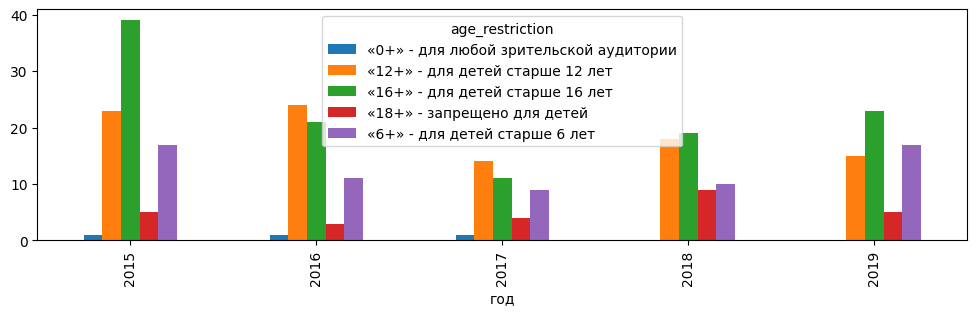

```python
# сводная таблица сгруппированных по году данных в разрезе возрастного ограничения, где значения это количество фильмов
gov_data.query('year_premier > 2014')\
.pivot_table(index = 'year_premier',columns = 'age_restriction', values = 'puNumber', aggfunc = 'count' )\
.plot(kind = 'bar',rot = 90, figsize = (12,3),xlabel = 'год');
```

- Рассмотрим бюджет фильмов с государственной поддержкой, его возвратную и невозвратную части

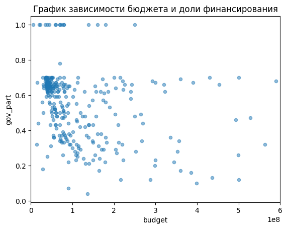

```python
# построим график зависимостибюджета и доли финансирования
gov_data.plot(kind = 'scatter',x = 'budget', y = 'gov_part', xlim = (0,600000000),\
              title = 'График зависимости бюджета и доли финансирования', alpha = 0.5);
```

Можно заметить, что большинство фильмов имеют господдержку от 0,2 до 0,7 доли от общего бюджета

```python
gov_data['gov_part'].describe()
```

```
count   318.00
mean      0.54
std       0.20
min       0.04
25%       0.38
50%       0.61
75%       0.66
max       1.00
Name: gov_part, dtype: float64
```

Медианное значение доли госфинансирования составляет около 62%, максимальное - 100%

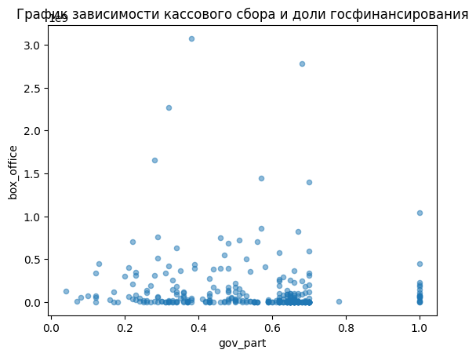

```python
# построим график зависимости кассового сбора и доли финансирования госструктурами
gov_data.plot(kind = 'scatter',x = 'gov_part', y = 'box_office',\
              title = 'График зависимости кассового сбора и доли госфинансирования',alpha = 0.5);
```

```python
print('Коэффициент корреляции кассового сбора и общего бюджета', round(gov_data['budget'].corr(gov_data['box_office']),2))
print('Коэффициент корреляции кассового сбора и доли финансирования', round(gov_data['gov_part']\
                                                                        .corr(gov_data['box_office']),2))
print('Коэффициент корреляции невозвратной части бюджета и общего бюджета', round(gov_data['budget']\
                                                                        .corr(gov_data['nonrefundable_support']),2))
print('Коэффициент корреляции возвратной части бюджета и общего бюджета', round(gov_data['budget']\
                                                                        .corr(gov_data['refundable_support']),2))
```

```
Коэффициент корреляции кассового сбора и общего бюджета 0.38
Коэффициент корреляции кассового сбора и доли финансирования -0.08
Коэффициент корреляции невозвратной части бюджета и общего бюджета 0.59
Коэффициент корреляции возвратной части бюджета и общего бюджета 0.64
```

Наблюдается слабая положительная корреляция между бюджетом фильма и кассовыми сборами.Очевидно что возвратная и невозвратная части бюджета имеют положительную корреляцию с общим бюджетом.Коэффициент финансирования и кассовые сборы имеют нулевую корреляцию, а значит успешность фильма и доля финансирования никак не зависит друг от друга.

Рассмотрим графики корреляции для бюджета, его частей и кассового сбора

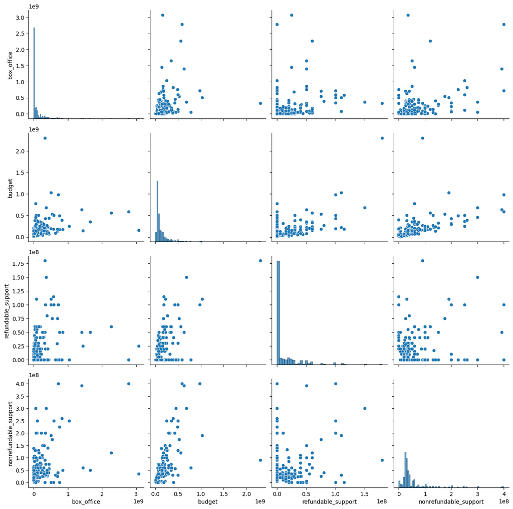

```python
sns.pairplot(gov_data[['box_office', 'budget', 'refundable_support', 'nonrefundable_support']])
plt.gcf().set_size_inches(13,13);
```

Чаще фильмы с господдержкой не имеют возвратной части бюджета, невозвратная часть чаще составляет сумму до 50 млн.рублей и зависит от бюджета фильма.Возвратная часть бюджета связана с бюджетом, на графике видим положительную связь. Кассовые сборы фильмов и бюджет имеют слабую положительную корреляцию, как и возвратная и невозвратная части бюджета.

- Анализ успешности фильмов финансируемых государством

Посчитаем количество фильмов провалившихся в прокате, т.е тех, чей бюджет превышает кассовый сбор

```python
down = gov_data.loc[gov_data['box_office'] < gov_data['budget']]['puNumber'].count()
total = gov_data['budget'].count()
print('Доля провалившихся в прокате фильмов с государственной поддержкой:',round((down/total*100),0),'%' )
```

```
Доля провалившихся в прокате фильмов с государственной поддержкой: 75.0 %
```

Внушительная часть фильмов провалилась в прокате, лишь четверть фильмов окупили свой бюджет

```python
# добавим столбец с информацией о разнице кассового сбора и бюджета
gov_data['difference'] = gov_data['box_office'] - gov_data['budget']
# рассчитаем коэффициент результативности
gov_data['perc_income'] = round(gov_data['box_office']/gov_data['budget'],2)
```

```python
# посмотрим на 5 самых провальных фильмов
gov_data.sort_values(by = 'difference').head(5)
```

|  | title | puNumber | show_start_date | type | film_studio | production_country | director | producer | age_restriction | refundable_support | nonrefundable_support | budget | financing_source | ratings | genres | box_office | year_premier | main_director | main_genres | gov_part | difference | perc_income |
| --- | --- | --- | --- | --- | --- | --- | --- | --- | --- | --- | --- | --- | --- | --- | --- | --- | --- | --- | --- | --- | --- | --- |
| 7114 | Тайна Печати Дракона | 111,012,819.00 | 2019-09-12 12:00:00+00:00 | Художественный | ООО "Кинокомпания "СТВ"; ООО "РФГ Корп"; ООО "... | Китай - Россия | О.Степченко | С.Сельянов, А.Петрухин | «6+» - для детей старше 6 лет | 180,000,000.00 | 90,000,000.00 | 2,305,074,303.00 | Фонд кино | 5.80 | приключения,фэнтези | 333,597,059.59 | 2019 | О.Степченко | приключения | 0.12 | -1,971,477,243.41 | 0.14 |
| 7171 | Грех | 111,014,419.00 | 2019-08-31 12:00:00+00:00 | Художественный | НО Фонд Андрея Кончаловского по поддержке кино... | Италия - Россия | А.Михалков (псевдоним А.Кончаловский) | НО Фонд Андрея Кончаловского по поддержке кино... | «16+» - для детей старше 16 лет | 0.00 | 60,000,000.00 | 779,941,965.00 | Министерство культуры | 6.90 | драма,биография,история | 54,243,202.71 | 2019 | А.Михалков (псевдоним А.Кончаловский) | драма | 0.08 | -725,698,762.29 | 0.07 |
| 5437 | Матильда | 111,005,717.00 | 2017-08-17 12:00:00+00:00 | Художественный | ООО "ТПО "РОК", ООО "Матильда" | Россия | А.Учитель | А.Учитель, А.Достман, В.Винокур | «16+» - для детей старше 16 лет | 110,000,000.00 | 190,000,000.00 | 1,032,905,957.00 | Фонд кино | 7.70 | фэнтези,комедия,семейный | 511,775,548.00 | 2017 | А.Учитель | фэнтези | 0.29 | -521,130,409.00 | 0.50 |
| 2142 | Территория | 111,000,515.00 | 2015-01-27 12:00:00+00:00 | Художественный | ООО "Творческое объединение "Кинокомпания "Анд... | Россия | А.Мельник | А.Мельник | «12+» - для детей старше 12 лет | 30,000,000.00 | 30,000,000.00 | 500,000,000.00 | Фонд кино | 6.80 | детектив,фэнтези,триллер | 72,578,317.40 | 2015 | А.Мельник | детектив | 0.12 | -427,421,682.60 | 0.15 |
| 6887 | Девятая | 111,007,019.00 | 2019-09-19 12:00:00+00:00 | Художественный | ООО "Нон-Стоп Продакшн" | Россия | Н.Хомерики | С.Мелькумов, А.Роднянский | «16+» - для детей старше 16 лет | 0.00 | 300,000,000.00 | 453,704,666.00 | Фонд кино | 5.80 | детектив,триллер,криминал | 55,876,887.40 | 2019 | Н.Хомерики | детектив | 0.66 | -397,827,778.60 | 0.12 |

Антирейтинг фильмов по успешности проката возглавляет фильм "Тайна печати Дракона", с суммой потерь в 1971477000 рублей.После идут 'Грех' и 'Матильда'

```python
# проверим финансирование провалившихся в прокате фильмов
gov_data.query('difference < 0')['financing_source'].value_counts()
```

```
Министерство культуры               135
Фонд кино                            83
Министерство культуры, Фонд кино     21
Name: financing_source, dtype: int64
```

```python
# посчитаем суммарную потерю фильмов, для фильмов провалившихся в прокате сгруппированных по источнику финансирования
gov_data.query('difference < 0').pivot_table(index = 'financing_source', values = 'difference', aggfunc = 'sum')
```

| financing_source | difference |
| --- | --- |
| Министерство культуры | -8,101,763,006.71 |
| Министерство культуры, Фонд кино | -1,859,346,236.44 |
| Фонд кино | -11,538,418,041.22 |

Большинство фильмов, провалившихся в прокате, финансировались Министерством культуры. Посчитав суммарную разницу между бюджетом и кассовым сбором фильмов, провалившихся в прокате, можно увидеть, что Фонд кино лидирует по финансированию убыточных фильмов.

```python
# посмотрим на 3 самых прибыльных  фильма
gov_data.sort_values(by = 'difference', ascending = False).head(3)
```

|  | title | puNumber | show_start_date | type | film_studio | production_country | director | producer | age_restriction | refundable_support | nonrefundable_support | budget | financing_source | ratings | genres | box_office | year_premier | main_director | main_genres | gov_part | difference | perc_income |
| --- | --- | --- | --- | --- | --- | --- | --- | --- | --- | --- | --- | --- | --- | --- | --- | --- | --- | --- | --- | --- | --- | --- |
| 7456 | Холоп | 111,021,719.00 | 2019-12-19 12:00:00+00:00 | Художественный | ООО "МЕМ-МЕДИА" по заказу АО "ВБД Груп" | Россия | К.Шипенко | Э.Илоян, Д.Жалинский, В.Дусмухаметов, Т.Бадзие... | «12+» - для детей старше 12 лет | 25,000,000.00 | 35,000,000.00 | 160,000,000.00 | Фонд кино | 6.80 | комедия | 3,073,568,690.79 | 2019 | К.Шипенко | комедия | 0.38 | 2,913,568,690.79 | 19.21 |
| 5653 | Движение вверх | 111,011,817.00 | 2017-12-21 12:00:00+00:00 | Художественный | ООО "Студия "ТРИТЭ" Никиты Михалкова" | Россия | А.Мегердичев | Л.Верещагин, А.Златопольский, Н.Михалков, ООО ... | «6+» - для детей старше 6 лет | 0.00 | 400,000,000.00 | 590,192,191.00 | Фонд кино | 7.50 | спорт,драма | 2,779,686,144.00 | 2017 | А.Мегердичев | спорт | 0.68 | 2,189,493,953.00 | 4.71 |
| 6549 | Т-34 | 111,024,918.00 | 2018-12-21 12:00:00+00:00 | Художественный | ООО "Кинокомпания МАРС-фильм" по заказу ООО "М... | Россия | А.Сидоров | А.Златопольский, Р.Дишдишян, Л.Блаватник, Н.Яр... | «12+» - для детей старше 12 лет | 60,000,000.00 | 120,000,000.00 | 563,784,717.00 | Фонд кино | 6.50 | драма,военный,боевик | 2,271,754,004.52 | 2018 | А.Сидоров | драма | 0.32 | 1,707,969,287.52 | 4.03 |

Самаым успешным фильмом с профитом в 2913569000 рублей является фильм "Холоп" 2019 г.

```python
# проверим источник финансирования успешных фильмов
gov_data.query('difference >= 0')['financing_source'].value_counts()
```

```
Фонд кино                           61
Министерство культуры               17
Министерство культуры, Фонд кино     1
Name: financing_source, dtype: int64
```

```python
# посчитаем прибыльность фильмов, имевших успех в прокате, сгруппировав данные по источнику финансирования
gov_data.query('difference >= 0').pivot_table(index = 'financing_source', values = 'difference', aggfunc = 'sum')
```

| financing_source | difference |
| --- | --- |
| Министерство культуры | 2,508,527,855.64 |
| Министерство культуры, Фонд кино | 15,375,045.70 |
| Фонд кино | 19,110,996,334.81 |

Успешные фильмы финансировались чаще 'Фонд культуры'

```python
# проверим в каком жанре чаще всего снимаются фильмы
gov_data['main_genres'].value_counts().head(5)
```

```
драма         100
комедия        73
мультфильм     31
триллер        15
мелодрама      14
Name: main_genres, dtype: int64
```

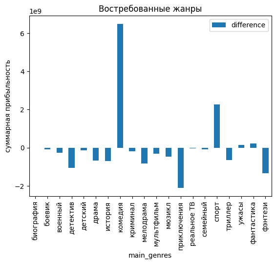

```python
gov_data.pivot_table(index = 'main_genres', values = 'difference', aggfunc = 'sum')\
.plot(kind = 'bar', title = 'Востребованные жанры', ylabel = 'суммарная прибыльность');
```

Самые прибыльные фильмы за исследуемый период с учетом потерь это 'комедии' и жанр 'спорт', самые убыточные в категории 'приключения' и 'фэнтези'. Популярный для финансирования жанр 'драма' по итогу оказался убыточным. Стоит добавить график медианного кассового сбора по жанрам

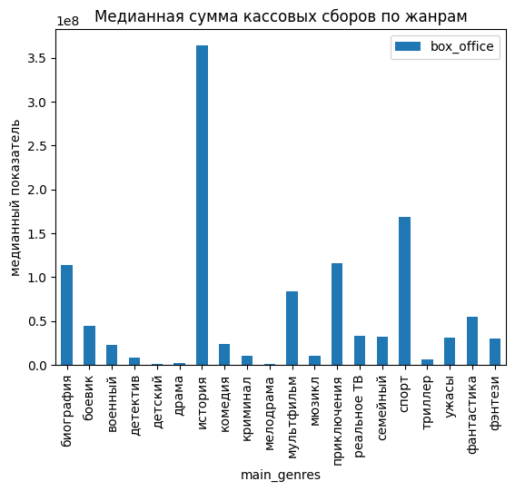

```python
# построим сводную таблицу, где посчитаем средний кассовый сбор по жанру
gov_data.pivot_table(index = 'main_genres', values = 'box_office', aggfunc = 'median')\
.plot(kind = 'bar', title = 'Медианная сумма кассовых сборов по жанрам', ylabel = 'медианный показатель');
```

По медианному значению кассового сбора лидируют жанр 'история' и 'спорт'. 'Детский', 'драма', 'мелодрамма' имеют самое низкое значение кассового сбора

Проведем анализ прибыльности по коэффициенту результативности

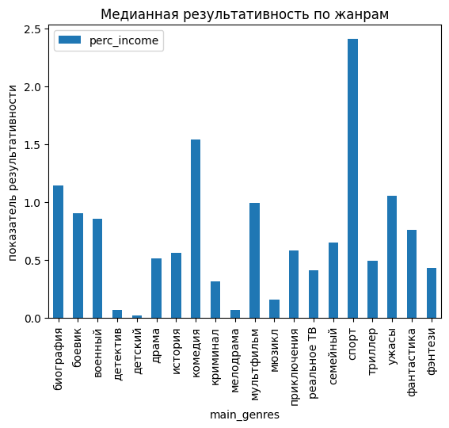

```python
# построим график самых результативных жанров
gov_data.pivot_table(index = 'main_genres', values = 'perc_income', aggfunc = 'mean')\
.plot(kind = 'bar', title = 'Медианная результативность по жанрам', ylabel = 'показатель результативности');
```

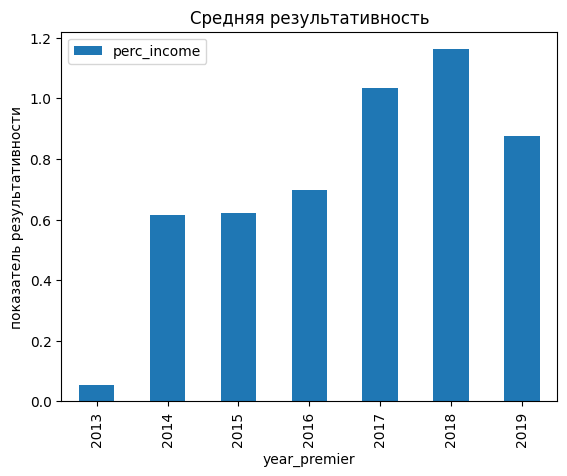

```python
# построим график самых успешных с точки зрения результативности лет
gov_data.pivot_table(index = 'year_premier', values = 'perc_income', aggfunc = 'mean')\
.plot(kind = 'bar', title = 'Средняя результативность', ylabel = 'показатель результативности');
```

```python
# 5-ка лучших фильмов с точки зрения результативности
gov_data.sort_values(by = 'perc_income',ascending = False).head(5)
```

|  | title | puNumber | show_start_date | type | film_studio | production_country | director | producer | age_restriction | refundable_support | nonrefundable_support | budget | financing_source | ratings | genres | box_office | year_premier | main_director | main_genres | gov_part | difference | perc_income |
| --- | --- | --- | --- | --- | --- | --- | --- | --- | --- | --- | --- | --- | --- | --- | --- | --- | --- | --- | --- | --- | --- | --- |
| 7456 | Холоп | 111,021,719.00 | 2019-12-19 12:00:00+00:00 | Художественный | ООО "МЕМ-МЕДИА" по заказу АО "ВБД Груп" | Россия | К.Шипенко | Э.Илоян, Д.Жалинский, В.Дусмухаметов, Т.Бадзие... | «12+» - для детей старше 12 лет | 25,000,000.00 | 35,000,000.00 | 160,000,000.00 | Фонд кино | 6.80 | комедия | 3,073,568,690.79 | 2019 | К.Шипенко | комедия | 0.38 | 2,913,568,690.79 | 19.21 |
| 5708 | Лёд | 111,000,518.00 | 2018-02-01 12:00:00+00:00 | Художественный | ООО "Водород 2011", ООО "Арт Пикчерс Студия", ... | Россия | О.Трофим | М.Врубель, А.Андрющенко, Ф.Бондарчук, Д.Рудовс... | «12+» - для детей старше 12 лет | 25,000,000.00 | 60,000,000.00 | 148,585,222.00 | Фонд кино | NaN | драма, комедия | 1,445,731,797.89 | 2018 | О.Трофим | драма | 0.57 | 1,297,146,575.89 | 9.73 |
| 5749 | Я худею | 111,001,618.00 | 2018-03-07 12:00:00+00:00 | Художественный | ООО "Друг Друга", ООО "Ди Пи Джи" | Россия | А.Черномазов (псевдоним Алексей Нужный) | С.Корнихин, Н.Куликов, А.Черномазов, А.Кремер,... | «16+» - для детей старше 16 лет | 0.00 | 30,000,000.00 | 87,649,127.00 | Министерство культуры | 6.90 | комедия | 633,462,266.74 | 2018 | А.Черномазов (псевдоним Алексей Нужный) | комедия | 0.34 | 545,813,139.74 | 7.23 |
| 3229 | Гуляй, Вася ! | 111,018,216.00 | 2016-12-20 12:00:00+00:00 | Художественный | ООО Кинокомпания "Инвада Фильм", АО "ВБД Груп" | Россия | Р.Каримов | А.Новиков, А.Котелевский, Э.Илоян, Д.Жалинский... | «16+» - для детей старше 16 лет | 0.00 | 25,345,000.00 | 39,000,000.00 | Министерство культуры | 6.50 | комедия | 259,099,078.00 | 2016 | Р.Каримов | комедия | 0.65 | 220,099,078.00 | 6.64 |
| 2058 | Дуxless 2 | 111,000,415.00 | 2015-01-26 12:00:00+00:00 | Художественный | ООО "Киностудия "Слово", ООО "Арт Пикчерс Студия" | Россия | Р.Прыгунов | П.Ануров, Ф.Бондарчук, Д.Рудовский | «16+» - для детей старше 16 лет | 0.00 | 75,000,000.00 | 75,000,000.00 | Фонд кино | 6.60 | драма | 446,163,511.00 | 2015 | Р.Прыгунов | драма | 1.00 | 371,163,511.00 | 5.95 |

В тройку самых результативных фильмов входят 'Холоп','Лёд' и 'Я худею' .В среднем высокий коэффициент показывают фильмы в жанре 'спорт' и 'комедия'.Средний показатель результативности выше всего в 2017 - 2018 гг.

Проверим уникальные значения столбца `main_director` и избавимся от неявных дубликатов

```python
# создадим список уникальных значений столбца main_director
family = sorted(gov_data['main_director'].unique())
```

```python
# создадим словарь и посчитаем количество вхождений слов начинающихся с большой буквы(фамилий)
dict = {}
for i in family:
    for d in range(len(i)-1):
        if i[d].isupper() and i[d+1] != '.':
            dict[i[d:d+6]] = dict.get(i[d:d+6],0)+1
        else:
            continue
```

```python
# создадим результирующий словарь, где проверяем только ключи словаря dict со значениями больше 2, с возможными неявными
# дубликатами
result = {}
for key in dict:
    if dict[key]>=2:
        for j in sorted(family):
            if key in j:
                result[key] = result.get(key,[]) + [j]
```

```python
result
```

```
{'Герман': ['А.Герман', 'Валерия Гай Германика'],
 'Зайцев': ['А.Зайцев', 'И.Зайцев'],
 'Ковале': ['А.Коваленко', 'К.Коваленко'],
 'Кончал': ['А.Кончаловский', 'А.Михалков (псевдоним А.Кончаловский)'],
 'Лунгин': ['А.Лунгин', 'П.Лунгин'],
 'Миндад': ['А.Миндадзе', 'Е.Миндадзе (псевдоним Катя Шагалова)'],
 'Михалк': ['А.Михалков',
  'А.Михалков (псевдоним А.Кончаловский)',
  'Н.Михалкова'],
 'Нужный': ['А.Нужный', 'А.Черномазов (псевдоним Алексей Нужный)'],
 'Сидоро': ['А.Сидоров', 'П.Сидоров'],
 'Соколо': ['А.Соколов', 'К.Соколов', 'С.Соколов'],
 'Учител': ['А.Учитель', 'И.Учитель'],
 'Аленик': ['В.Алеников', 'Т.Аленикова'],
 'Куценк': ['Г.Куценко (Ю.Куценко)'],
 'Волков': ['И.Волкова', 'М.Волков'],
 'Максим': ['И.Максимов', 'К.Максимов', 'Максим Свешников'],
 'Белеви': ['К.Белевич', 'К.Белевич (псевдоним - Кирилл Астахов)'],
 'Василь': ['К.Васильев', 'Р.Артемьев (псев.С.Васильев)', 'Ю.Васильев'],
 'Оганес': ['К.Оганесян', 'Э.Оганесян'],
 'Бальчю': ['М.Бальчюнас', 'М.Бальчюнас (псевдоним Марюс Вайсберг)'],
 'Свешни': ['М.Свешников', 'Максим Свешников'],
 'Бондар': ['Н.Бондарчук', 'Ф.Бондарчук'],
 'Лопато': ['Н.Лопато', 'О.Лопато'],
 'Артемь': ['Р.Артемьев', 'Р.Артемьев (псев.С.Васильев)'],
 'Попов': ['О.Попова', 'С.Попов', 'Ф.Попов', 'Ю.Попович'],
 'Игумен': ['Т.Игуменцева', 'Т.Игуменцева (псевдоним Татьяна Капитан)']}
```

```python
# замена неявных дубликатов
gov_data['main_director'] = gov_data['main_director'].replace('Р.Артемьев (псев.С.Васильев)','Р.Артемьев')
gov_data['main_director'] = gov_data['main_director'].replace('М.Бальчюнас (псевдоним М.Вайсберг)','М.Бальчюнас')
gov_data['main_director'] = gov_data['main_director'].replace('М.Бальчюнас (псевдоним Марюс Вайсберг)','М.Бальчюнас')
gov_data['main_director'] = gov_data['main_director'].replace('К.Белевич (псевдоним - Кирилл Астахов)','К.Белевич')
gov_data['main_director'] = gov_data['main_director'].replace('Т.Игуменцева (псевдоним Татьяна Капитан)','Т.Игуменцева')
gov_data['main_director'] = gov_data['main_director'].replace('А.Михалков (псевдоним А.Кончаловский)','А.Михалков')
gov_data['main_director'] = gov_data['main_director'].replace('А.Черномазов (псевдоним Алексей Нужный)','А.Нужный')
gov_data['main_director'] = gov_data['main_director'].replace('Максим Свешников','М.Свешников')
```

```python
# выведем 5 имен из список наиболее часто встречающихся главных режиссеров
gov_data['main_director'].value_counts().head(5)
```

```
Р.Давлетьяров    5
С.Андреасян      4
Д.Дьяченко       4
Д.Шмидт          3
А.Аксененко      3
Name: main_director, dtype: int64
```

Проверим насколько успешны фильмы режиссеров, которые получают наибольшее число одобренных заявок на финансирование

```python
gov_data.query('(main_director in ["Р.Давлетьяров","Д.Дьяченко","С.Андреасян","Н.Хомерики","А.Аксененко","М.Бальчюнас"]) \
and difference > 0').sort_values(by = 'main_director')
```

|  | title | puNumber | show_start_date | type | film_studio | production_country | director | producer | age_restriction | refundable_support | nonrefundable_support | budget | financing_source | ratings | genres | box_office | year_premier | main_director | main_genres | gov_part | difference | perc_income |
| --- | --- | --- | --- | --- | --- | --- | --- | --- | --- | --- | --- | --- | --- | --- | --- | --- | --- | --- | --- | --- | --- | --- |
| 3135 | Чемпионы: Быстрее. Выше. Сильнее | 111,021,115.00 | 2015-12-22 12:00:00+00:00 | Художественный | ООО "Энджой мувиз" | Россия | А.Аксененко | Г.Малков, В.Поляков | «6+» - для детей старше 6 лет | 0.00 | 40,000,000.00 | 90,276,774.00 | Фонд кино | 7.00 | спорт,драма | 168,688,859.10 | 2015 | А.Аксененко | спорт | 0.44 | 78,412,085.10 | 1.87 |
| 2767 | Страна чудес | 111,018,415.00 | 2015-10-16 12:00:00+00:00 | Художественный | ООО "Ол Медиа Компани" | Россия | Д.Дьяченко | Г.Шабанов, Р.Татаринцев, Э.Илоян | «12+» - для детей старше 12 лет | 41,000,000.00 | 25,000,000.00 | 105,445,546.00 | Фонд кино | 6.00 | ужасы,комедия | 294,590,750.60 | 2015 | Д.Дьяченко | ужасы | 0.63 | 189,145,204.60 | 2.79 |
| 2872 | Супербобровы | 111,004,716.00 | 2016-03-01 12:00:00+00:00 | Художественный | ООО "КЕЙСТОУН ПРОДАКШН ГРУП" по заказу ООО "Фи... | Россия | Д.Дьяченко | Э.Илоян, В.Шляппо, А.Троцюк, Д.Жалинский, Д.Дь... | «12+» - для детей старше 12 лет | 40,000,000.00 | 25,000,000.00 | 150,008,573.00 | Фонд кино | 4.90 | комедия,семейный,фантастика | 270,538,437.90 | 2016 | Д.Дьяченко | комедия | 0.43 | 120,529,864.90 | 1.80 |
| 5505 | Последний богатырь | 111,007,017.00 | 2017-10-19 12:00:00+00:00 | Художественный | ООО "Киностудия "Слово" по заказу ООО "Уолт Ди... | Россия | Д.Дьяченко | Э.Илоян, Д.Жалинский, М.Озкан, А.Троцюк, В.Шляппо | «12+» - для детей старше 12 лет | 50,000,000.00 | 50,000,000.00 | 352,477,575.00 | Фонд кино | 6.80 | комедия,фэнтези,приключения | 1,655,037,688.00 | 2017 | Д.Дьяченко | комедия | 0.28 | 1,302,560,113.00 | 4.70 |
| 6320 | СУПЕРБОБРОВЫ. НАРОДНЫЕ МСТИТЕЛИ | 111,020,318.00 | 2018-10-20 12:00:00+00:00 | Художественный | ООО "Кейстоун продакшн груп" по заказу АО "ВБД... | Россия | Д.Дьяченко | Э.Илоян, В.Шляппо, Д.Жалинский, А.Троцюк | «12+» - для детей старше 12 лет | 40,000,000.00 | 80,000,000.00 | 172,763,618.00 | Фонд кино | 4.90 | комедия,семейный | 184,731,757.62 | 2018 | Д.Дьяченко | комедия | 0.69 | 11,968,139.62 | 1.07 |
| 2205 | 8 новых свиданий | 111,014,914.00 | 2014-10-30 12:00:00+00:00 | Художественный | ООО "Смарт ТВ Продакшн" | Россия | М.Бальчюнас | ООО "Грин Филмс", ООО "ПЦ "Горад" | «12+» - для детей старше 12 лет | 0.00 | 30,000,000.00 | 77,401,751.00 | Фонд кино | 6.00 | комедия | 393,344,626.30 | 2014 | М.Бальчюнас | комедия | 0.39 | 315,942,875.30 | 5.08 |
| 6632 | Бабушка лёгкого поведения 2 | 111,000,519.00 | 2019-01-23 12:00:00+00:00 | Художественный | ООО "Вайс Филмс" | Россия | М.Бальчюнас (псевдоним Марюс Вайсберг) | А.Ревва, М.Бальчюнас (псевдоним Марюс Вайсберг) | «16+» - для детей старше 16 лет | 0.00 | 40,000,000.00 | 101,463,696.00 | Министерство культуры | 5.30 | комедия | 439,776,371.25 | 2019 | М.Бальчюнас | комедия | 0.39 | 338,312,675.25 | 4.33 |
| 5673 | Селфи | 111,012,117.00 | 2018-02-01 12:00:00+00:00 | Художественный | ООО "Киностудия "Слово", ООО "Арт Пикчерс Студия" | Россия | Н.Хомерики | П.Ануров, Ф.Бондарчук, Д.Рудовский | «16+» - для детей старше 16 лет | 20,000,000.00 | 40,000,000.00 | 60,000,000.00 | Фонд кино | 5.80 | триллер,драма | 225,196,400.03 | 2018 | Н.Хомерики | триллер | 1.00 | 165,196,400.03 | 3.75 |
| 1870 | А зори здесь тихие..._ | 111,002,915.00 | 2015-03-16 12:00:00+00:00 | Художественный | ООО "Компания "Реал-Дакота" | Россия | Р.Давлетьяров | NaN | «12+» - для детей старше 12 лет | 50,000,000.00 | 100,000,000.00 | 220,588,394.00 | Фонд кино | 8.50 | драма,военный,история | 249,166,767.70 | 2015 | Р.Давлетьяров | драма | 0.68 | 28,578,373.70 | 1.13 |
| 6178 | Непрощенный | 111,016,018.00 | 2018-09-27 12:00:00+00:00 | Художественный | ООО "Кинокомпания Большое кино" | Россия | С.Андреасян | С.Андреасян, Г.Андреасян, А.Ананикян | «16+» - для детей старше 16 лет | 0.00 | 40,000,000.00 | 82,496,889.00 | Министерство культуры | 6.70 | драма | 393,279,629.43 | 2018 | С.Андреасян | драма | 0.48 | 310,782,740.43 | 4.77 |

Главный режиссер Д.Дьяченко снимает фильмы которые окупаются в прокате, Р.Давлетьяров, который имеет наибольшее количество одобреной господдержки снял 1 фильм, чей кассовый сбор првышает бюджет. С.Андреасян снял 1 успешный фильм из 4. А.Аксененко, Н.Хомерики также по 1 из 3. М.Бальчюнас снял 2 успешных фильма из 3.

Вывод: Финансирование государственными фондами большей частью приходится на фильмы с низкой результативностью, больше деньги выделяются на драмы, но комедии и спорт чаще делают кассовый сбор. Самой кассовой комедией является фильм 'Холоп', в спортивном жанре 'Движение вверх', драма - фильм 'Т-34'. Как правило финансирование получают разные режиссеры, но есть и повторы финансирования одного режиссера, не всегда успешные. На поддержку госфондов приходится как правило около 60 % бюджета фильма, причем большая доля за невозвратной частью бюджета.

### Вывод:

В имеющихся данных средний рейтинг фильмов равен 6.3 балла.Данные кассовых сборов имеют разный способ подсчета, поэтому описательный анализ для столбца разделен на 2 периода: до 2014 и после для корректности исследования.Фильмы с поддержкой государства чаще не имеют части возвратного бюджета, невозвратный же составляет от 0 до 400 млн. Общий бюджет таких фильмов составляет 71 млн в медианном значении. Количество прокатных удостоверений меняется от года к году , наибольшее количество, чуть менее 1000, выдано в 2010, наименьшее в 2017 с последующем максимальным ростом за исследуемый период. В имеющихся данных количество прокатных удостоверений с указанной суммой кассовых сборов - 3133, что составляет 42% от общего количества прокатных удостоверений. При визуальной оценке изменения количества указанных кассовых сборов от года к году видим постепенное изменение в сторону увеличения представления информации, если в 2010 году соотношение наличия/отсутствия кассовых сборов было примерно 1 к 8, то после 2014 года пропорция изменилась и составляла уже 1 к 2 в сторону представленности данных(наличия информации о кассовых сборах). В процентном соотношении с 2010 до 2015 года видим уверенный прирост доли информации о box_office, в среднем на примерно 5 % в год. С 2015 года видим прирост почти в 50%, после уровень представленности остается на довольно высоком уровне,показывая незначительные снижения в 2017 -2018годах. Суммарный кассовый сбор следует рассматривать в 2 временных периодах: до 2014 и после .С 2015 года сумма box_office показывает некоторую стабильность, макимальный рост с 2014 по 2015, максимальная сумма сбора в 2018 году и составляет около 45 млрд.Период до 2014 имеет низкие показатели box_office, минимум в 2010г с суммой примерно в 2,5 млн, что возможно связано с дркгим способ исчисления.

Согласно исследуемым данным 75% фильмов финансируемых госфондами провалились в прокате, причем большинство из них одобрены Министерсвом культуры, наибольшие потери связаны с фильмом 'Печать Дракона' и суммой почти в 2 млрд.рублей. Тройка кассовых фильмов : "Холоп", "Движение вверх", "Т-34". Предпочтение в финансировании отдается жанру 'драма', когда как 'комедии' и 'спорт' показывают лучшие результаты по прибыльности с учетом потерь. Медианный показатель у жанра 'история' один из самых высоких, у 'драм',"детский", "мелодрама" - низкие показатели. Государственное финансирование оказывалось максимум 5 раз одному и тому же главному режиссеру, Р.Давлетьярову, из 5 фильмов только 1 собрал хороший кассовый сбор. Д.Дьяченко стал одним из самых успешных режиссеров, из 4 фильмов - 4 с кассовыми сборами превышающими бюджет.

Если считать миссией государственного софинансирования фильмов поддержку отчественного кинопроизводителя, повышение конкурентоспособности отечественного кино и поддерждания социально-значимой повестки будет верным предположить, что безусловно выполняется финподдержка. Рейтинги российских фильмов без господдержки по среднему показателю выше, чем фильмы с господдержкой за исключением 2015г. Суммарный же и медианные показатели кассового сбора при примерно одинаковом количестве фильмов за наблюдаемый период сильно уступают фильмам с господдержкой. Возможно стоит пересмотреть критерии отбора для финансирования в сторону актуализации социально-значимой повестки, ужесточению сценарных критериев для соответствия ожиданиниям потребителя.